# Problem set 1: Single-species models in discrete time

### 1. Modify the following code to determine the long-term behavior of the discrete-time logistic growth model. In the example below, the population moves towards an equilbrium point. How does the long-term behavior change as you increase *r* slowly.

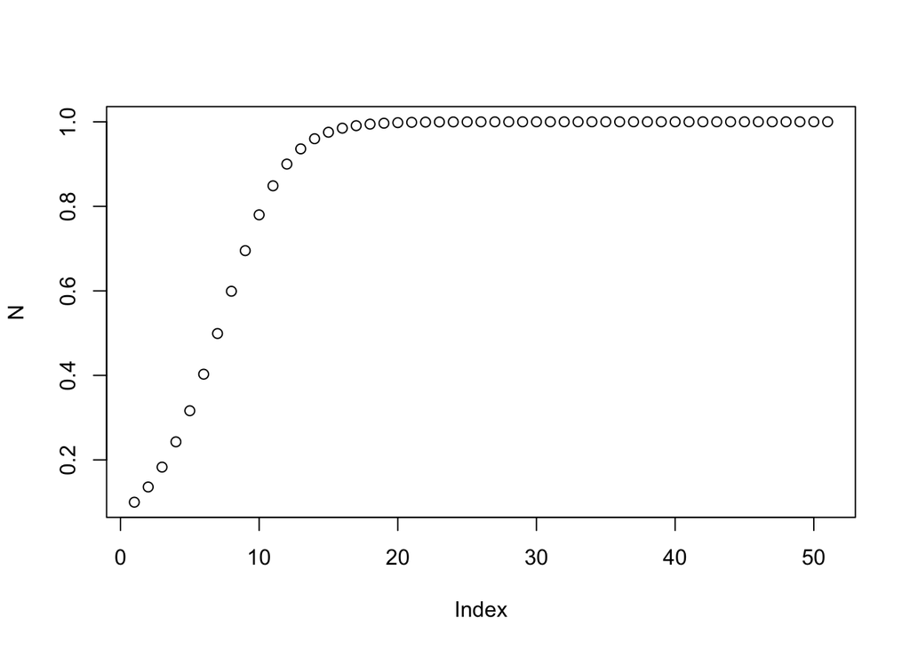

```r
# Parameters
max_time = 50
r = 0.4
K = 1

N = vector('numeric',length=max_time)
N[1] = 0.1

# Iterate model
for (t in 1:max_time){
  N[t+1] = N[t] + r*N[t]*(1 - N[t]/K)
}

plot(N)
```

### 2. To show the results in question 1 more clearly, write R code to build a plot of the equilibrium value versus the value for $r$. To do this, run the model for 50 years, and only plot the last 10 years. If the solution is an equilibrium point, all 10 years should be the same value.s

### 3. Fisheries example

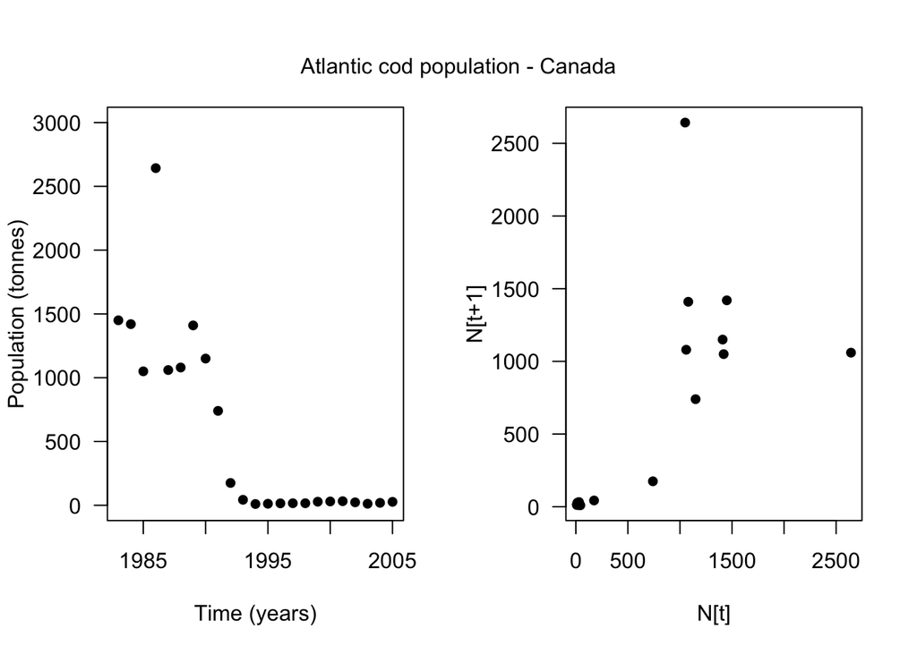

Left: Canadian Atlantic cod population (in tonnes) over time and Right: Phase plane plot of the Atlantic cod population

```r
cod_pop <- c(1450, 1420, 1050, 2643, 1060, 1080, 1410, 1150, 740, 175, 43, 10, 12, 15, 16, 16, 28, 30, 32, 23, 12, 19, 27)
years <- c(1983, 1984, 1985, 1986, 1987, 1988, 1989, 1990, 1991, 1992,
1993, 1994, 1995, 1996, 1997, 1998, 1999, 2000, 2001, 2002, 2003,
2004, 2005)

par(mfrow=c(1,2))
plot(years,cod_pop,ylim=c(0,3000),las=1,ylab='Population (tonnes)',xlab='Time (years)',pch=16)
plot(cod_pop[1:(length(cod_pop)-1)],cod_pop[2:length(cod_pop)],ylab='N[t+1]',xlab='N[t]',las=1,pch=16)

mtext(text = 'Atlantic cod population - Canada',side = 3,line = -3,outer=T)
```

In order to increase fisheries yields, models of fish populations have been used. Two common models are Beverton-Holt and the Ricker. Here we will use the Beverton-Holt model with parameters *a* and *b*:

$$N(t+1) = \frac{a N(t)}{1 + b N(t)}$$

You have two questions to address:

#### 3a) What are the parameter values (*a* and *b*) that best fit the data in phase plane diagram above?

#### 3b) For the best fit model, what is the optimal level of harvesting (*h*) that maximizes yield and prevents the population from going below 100 tonnes over a 50 year period? Use the modified Beverton-Holt model with a harvesting rate of *h*:

$$N(t+1) = (1-h) \frac{a N(t)}{1 + b N(t)}$$